# Effects of time and user information on trips duration

## Investigation Overview

In this investigation, I wanted to look at these features and see how it affect the trips duration. The main focus will be on the time information and the user information

## Dataset Overview

This data set includes information about individual rides made in a bike-sharing system covering the greater San Francisco Bay area. The columns have information about trip duration, member information, time information, and station information.

## Trips Duration Distribution

Most trips take less than 20 minutes.

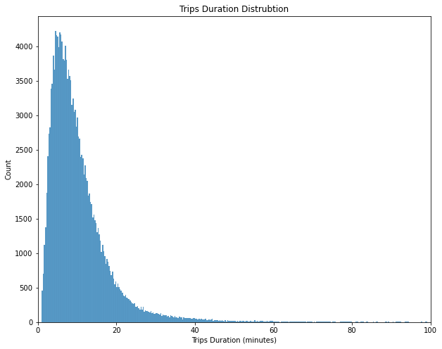

## Duration vs. Age

The relationship between members' age and trips duration is negative.

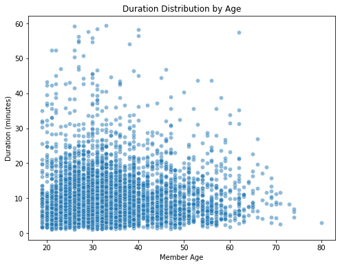

## Duration by User Type and Start Time of Day

On all days, customers go on longer trips than subscribers, especially at midnight and midday.

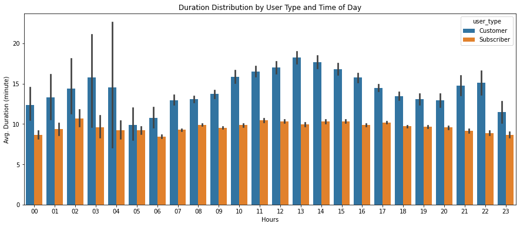

## Duration by User Type and Days of the Week

The trip duration increases for customers on the weekends, but for subscribers, it is consistent during all days.

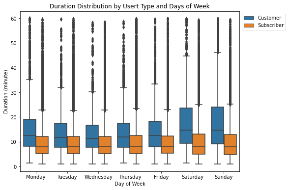

## Duration by Gender and User Type

Females go on long-duration trips than males, no matter they are subscribers or customers.

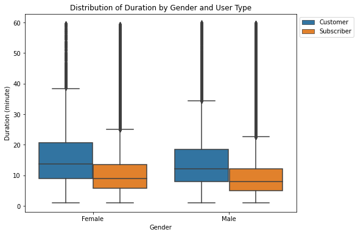

## Age by User Type and Gender

From the graph, we got a reason for why females go on longer duration trips than males. Females are younger than males, and the relationship between duration and ages is negative.

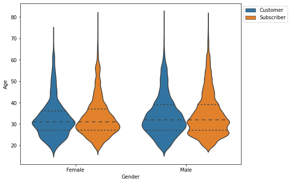